# 2.exploration (exercises)

```r
#table
diamonds |>
  count(color, cut) |>
  pivot_wider(
    names_from = color,
    values_from = n
  )
```

```
## # A tibble: 5 × 8
##   cut           D     E     F     G     H     I     J
##   <ord>     <int> <int> <int> <int> <int> <int> <int>
## 1 Fair        163   224   312   314   303   175   119
## 2 Good        662   933   909   871   702   522   307
## 3 Very Good  1513  2400  2164  2299  1824  1204   678
## 4 Premium    1603  2337  2331  2924  2360  1428   808
## 5 Ideal      2834  3903  3826  4884  3115  2093   896
```

c) Use geom_tile() together with dplyr to explore how average flight delays vary by destination and month of year. What makes the plot difficult to read? How could you improve it?

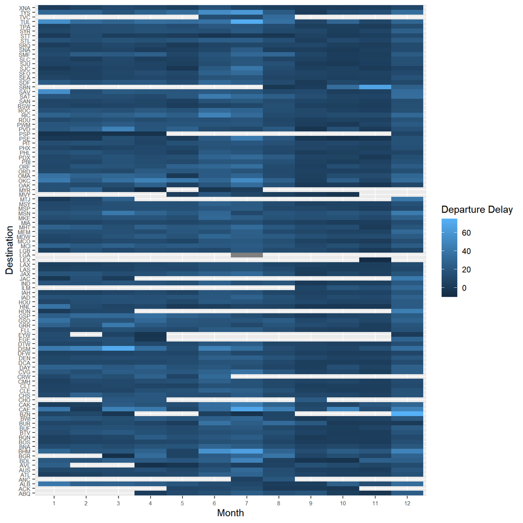

```r
#simple plot
flights |>
  group_by(month, dest) |>
  summarise(
    dep_delay = mean(dep_delay, na.rm = TRUE)
  ) |>
  ggplot(aes(x = factor(month), y = dest, fill = dep_delay)) +
  geom_tile() +
  labs(x = "Month", y = "Destination", fill = "Departure Delay") +
  theme(axis.text = element_text(size=6))
```

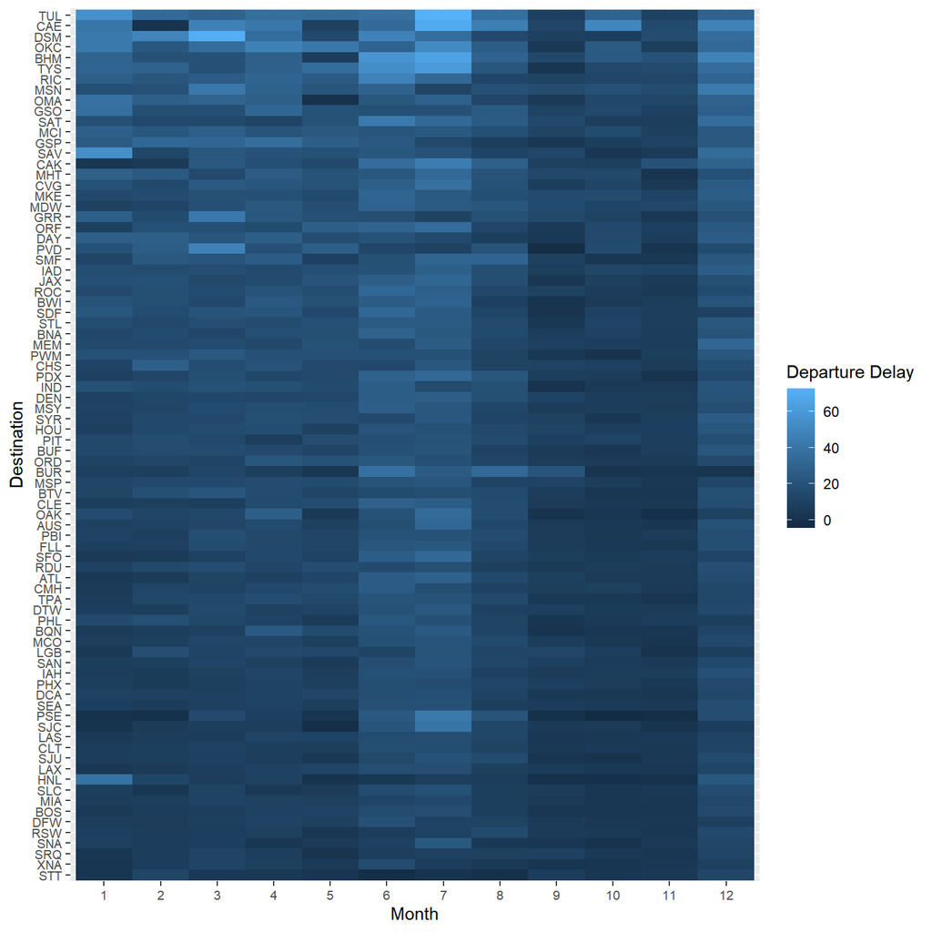

```r
#updated plot
flights |>
  group_by(month, dest) |>
  summarise(
    dep_delay = if_else(n() > 5, mean(dep_delay, na.rm = TRUE), NA),
    .groups = "drop"
  ) |>
  complete(month, dest) |>
  mutate(
    dest_with_na = any(is.na(dep_delay)),
    .by = dest
  ) |>
  filter(!dest_with_na) |>
  mutate(dest = reorder(dest, dep_delay)) |>
  ggplot(aes(x = factor(month), y = dest, fill = dep_delay)) +
  geom_tile() +
  labs(x = "Month", y = "Destination", fill = "Departure Delay")  +
  theme(axis.text = element_text(size=8))
```

## 3.3. TWO NUMERICAL VARIABLES

a) Instead of summarizing the conditional distribution with a box plot, you could use a frequency polygon. What do you need to consider when using cut_width() vs cut_number()? How does that impact a visualization of the 2d distribution of carat and price?

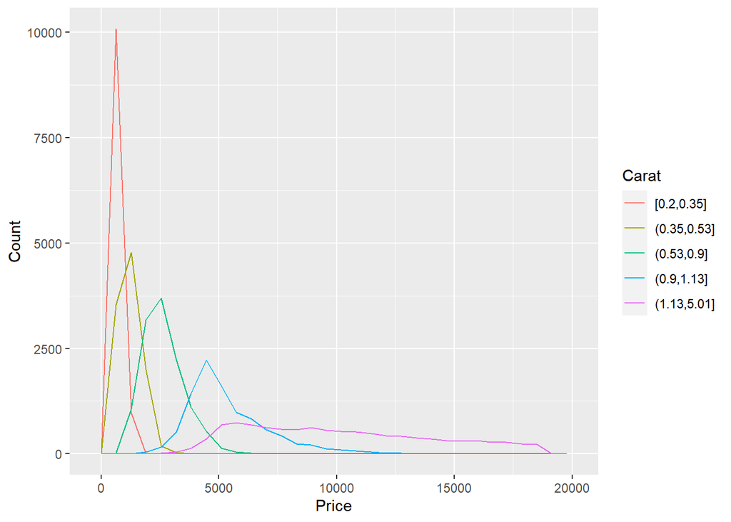

```r
#geom_freqpoly() with cut_number()
ggplot(diamonds, aes(color = cut_number(carat, 5), x = price)) +
  geom_freqpoly() +
  labs(x = "Price", y = "Count", color = "Carat")
```

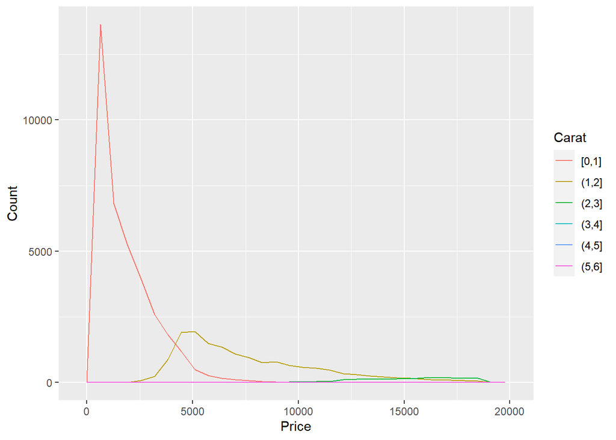

```r
#geom_freqpoly() with cut_width()
ggplot(diamonds, aes(color = cut_width(carat, 1, boundary = 0), x = price)) +
  geom_freqpoly() +
  labs(x = "Price", y = "Count", color = "Carat")
```

b) Visualize the distribution of carat, partitioned by price.

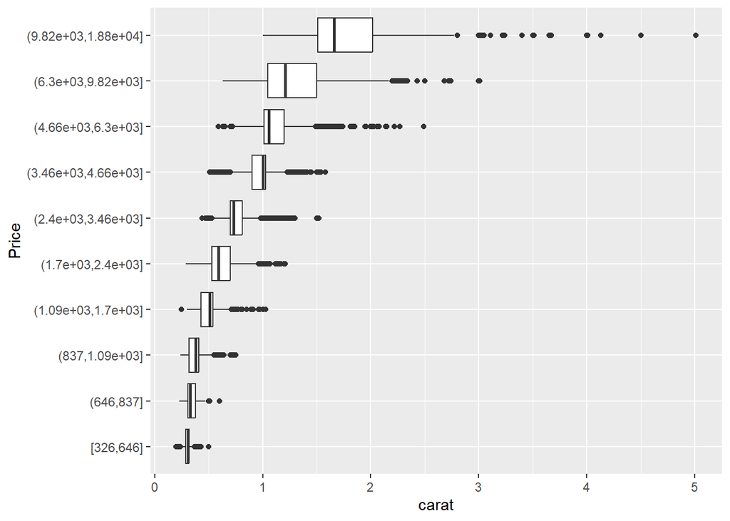

```r
#geom_boxplot() with cut_number()
ggplot(diamonds, aes(x = carat, y = cut_number(price, 10))) +
  geom_boxplot() +
  labs(y = "Price")
```

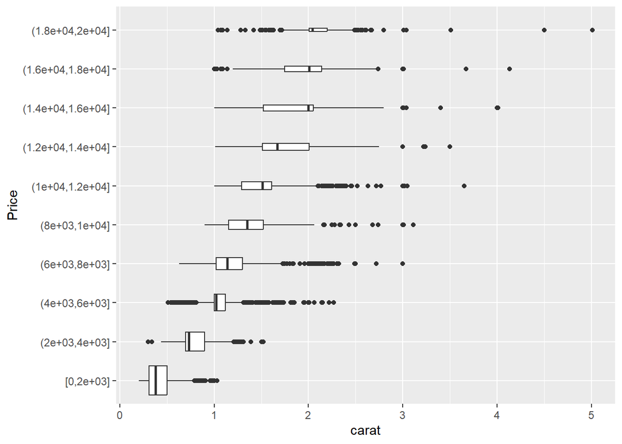

```r
#geom_boxplot() with cut_width()
ggplot(diamonds, aes(x = carat, y = cut_width(price, 2000, boundary = 0))) +
  geom_boxplot(varwidth = TRUE) +
  labs(y = "Price")
```

c) How does the price distribution of very large diamonds compare to small diamonds. Is it as you expect, or does it surprise you?

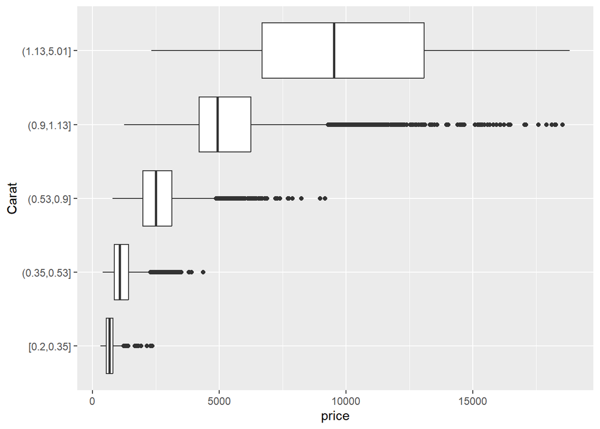

```r
ggplot(diamonds, aes(x = price, y = cut_number(carat, 5))) +
  geom_boxplot() +
  labs(y = "Carat")
```

d) Combine two of the techniques you’ve learned to visualize the combined distribution of cut, carat, and price.

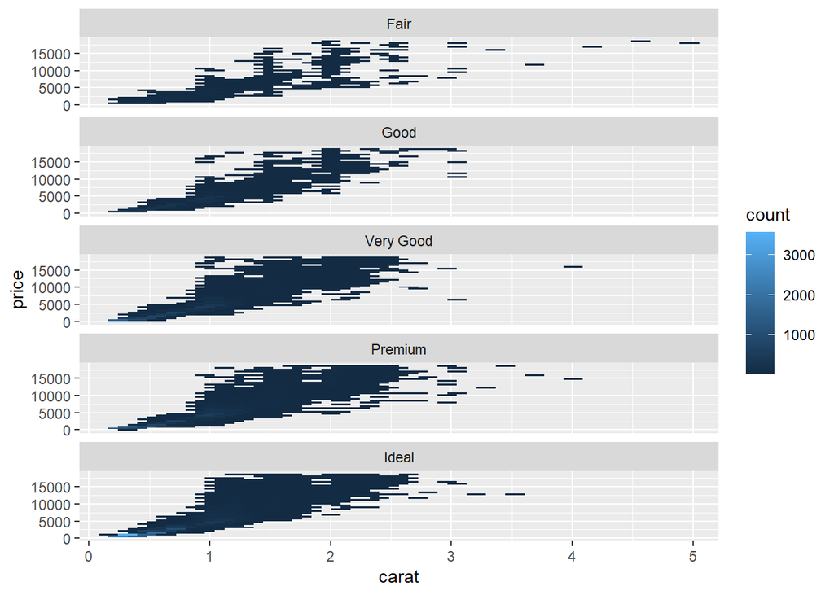

```r
#geom_hex() and facet_wrap()
ggplot(diamonds, aes(x = carat, y = price)) +
  geom_hex() +
  facet_wrap(~cut, ncol = 1)
```

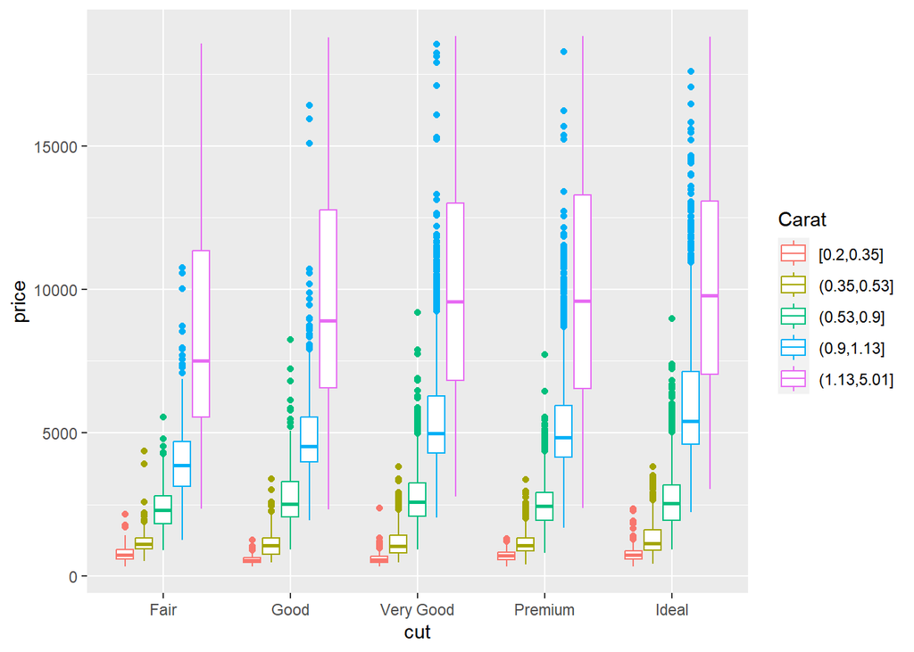

```r
#geom_boxplot() and colour
ggplot(diamonds, aes(x = cut, y = price, colour = cut_number(carat, 5))) +
  geom_boxplot() +
  labs(colour = "Carat")
```

e) Two dimensional plots reveal outliers that are not visible in one dimensional plots. For example, some points in the plot below have an unusual combination of x and y values, which makes the points outliers even though their x and y values appear normal when examined separately. Why is a scatterplot a better display than a binned plot for this case?

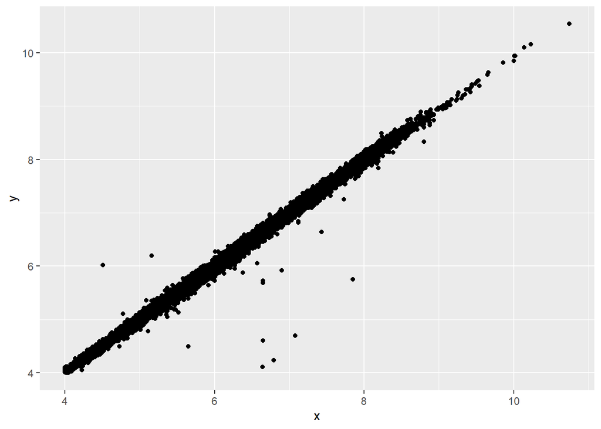

```r
diamonds |>
  filter(between(x, 4, 11), between(y, 4, 11)) |>
  ggplot(aes(x = x, y = y)) +
  geom_point()
```

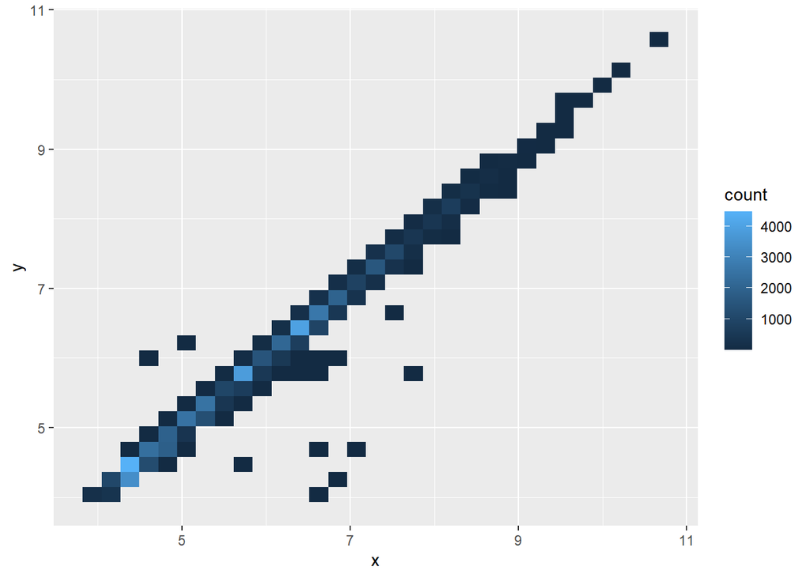

```r
diamonds |>
  filter(between(x, 4, 11), between(y, 4, 11)) |>
  ggplot(aes(x = x, y = y)) +
  geom_bin2d()
```

# 4. PATTERNS AND MODELS

```r
library("tidymodels")
library("tidyverse")
```

a) Obtain a sample with 20 observation from the dataset diamonds. Make the appropriate data transformation and fit a linear model between the price and the weight of diamonds. Plot the observations, the fitted value and the residuals. Take a look at geom_segment() for plotting the residuals.

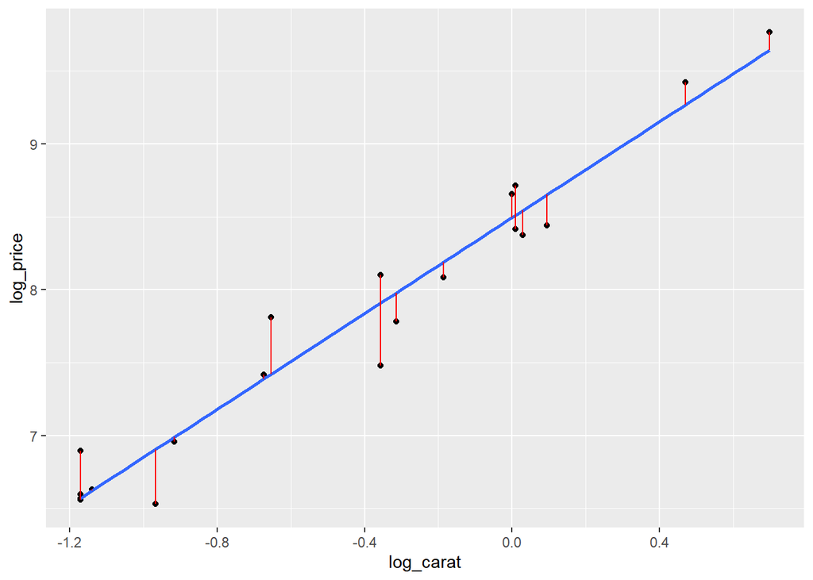

```r
set.seed(123)
diamonds2 <- diamonds |>
  mutate(
    log_price = log(price),
    log_carat = log(carat)
  ) |>
  slice_sample(n = 20)

diamonds_fit <- linear_reg(engine = "lm") |>
  fit(log_price ~ log_carat, data = diamonds2)

augment(diamonds_fit, new_data = diamonds2) |>
  ggplot(aes(x = log_carat, y = log_price)) +
  geom_point() +
  stat_smooth(method = "lm", formula = "y ~ x", se = FALSE) +
  geom_segment(aes(xend = log_carat, yend = .pred), color = "red")
```